# Homework_Week_2

Question 4.1

Describe a situation or problem from your job, everyday life, current events, etc., for which a clustering model would be appropriate. List some (up to 5) predictors that you might use.

One example is cellular clustering cells based on identity. We can cluster cells in blood samples based on size and morphology or granularity (complexity). Machines used to sort cells (Fluorescence activated cell sorters). Can cluster cells based on size, shape and fluorescence of certain biomarkers.

Predictors: 1.Size 2.Shape 3.fluorescence

Question 4.2

The iris data set iris.txt contains 150 data points, each with four predictor variables and one categorical response. The predictors are the width and length of the sepal and petal of flowers and the response is the type of flower. The data is available from the R library datasets and can be accessed with iris once the library is loaded. It is also available at the UCI Machine Learning Repository (https://archive.ics.uci.edu/ml/datasets/Iris ). The response values are only given to see how well a specific method performed and should not be used to build the model.

Use the R function kmeans to cluster the points as well as possible. Report the best combination of predictors, your suggested value of k, and how well your best clustering predicts flower type.

#### Answer

To get the best predictors we can do some exploratory data analysis. This blog [For more info check this site](https://www.geeksforgeeks.org/exploratory-data-analysis-on-iris-dataset/) gives examples of data exploration of the iris dataset in python. I picked pairplot to look at all of the relationships between the features using the GGally library in R.

```r
#install.packages("outliers")
#install.packages("GGally")
#install.packages("qcc")

#### Load iris dataset as df and load R libraries
library(GGally)
library(ggplot2)
library(datasets)
library(ggplot2)
library(dplyr)
library(outliers)
library(tidyr)
library(qcc)
df <- iris
summary(df)
```

```
  Sepal.Length    Sepal.Width     Petal.Length    Petal.Width          Species
 Min.   :4.300   Min.   :2.000   Min.   :1.000   Min.   :0.100   setosa    :50
 1st Qu.:5.100   1st Qu.:2.800   1st Qu.:1.600   1st Qu.:0.300   versicolor:50
 Median :5.800   Median :3.000   Median :4.350   Median :1.300   virginica :50
 Mean   :5.843   Mean   :3.057   Mean   :3.758   Mean   :1.199
 3rd Qu.:6.400   3rd Qu.:3.300   3rd Qu.:5.100   3rd Qu.:1.800
 Max.   :7.900   Max.   :4.400   Max.   :6.900   Max.   :2.500
```

```r
head(df)
```

|  | Sepal.Length | Sepal.Width | Petal.Length | Petal.Width | Species |
| --- | --- | --- | --- | --- | --- |
| 1 | 5.1 | 3.5 | 1.4 | 0.2 | setosa |
| 2 | 4.9 | 3.0 | 1.4 | 0.2 | setosa |
| 3 | 4.7 | 3.2 | 1.3 | 0.2 | setosa |
| 4 | 4.6 | 3.1 | 1.5 | 0.2 | setosa |
| 5 | 5.0 | 3.6 | 1.4 | 0.2 | setosa |
| 6 | 5.4 | 3.9 | 1.7 | 0.4 | setosa |

The ggpairs function can be used to make a pairplot of the iris dataset. In this case I used color to visualize the species (response column) of flowers for each predictor (sepal and petal width and length).

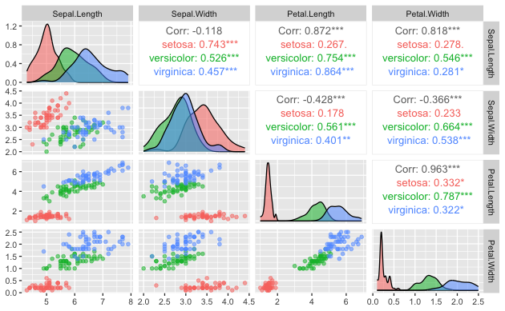

```r
#### Visualizing of distribution of potential clusters in the iris dataset
pairplot <- ggpairs(df,
        columns = 1:4,
        aes(color = Species, alpha = 0.5)) #transparency of 0.5) # scatter plots to visualize continous data

pairplot
```

```r
NA
NA
NA
NA
```

The diagonal boxes gives us the frequency distribution for each predictor column for each plant type, the upper boxes gives us the correlation coefficient and the bottom boxes gives us the scatterplots comparing predictors against each other for each plant type.

Before we determine the best k, we are going to scale the data for all of the 4 predictor variables excluding the response (in this case the species column)

```r
df_scaled <- scale(df[,1:4])
```

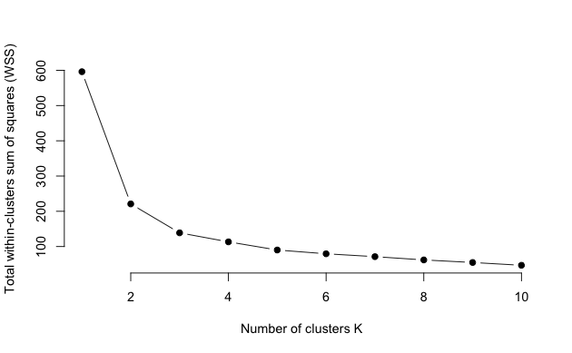

```r
#### Determining the best K using the "Elbow Method"
set.seed(1) #for reproducibility

WSS <- numeric() # results for WSS for each K stored here as a numeric value
k_values <- 1:10

for (k in k_values) {
  kmeans_model_iris <- kmeans(df_scaled, centers = k, nstart=20)
  WSS[k] <- kmeans_model_iris$tot.withinss #calculates WSS for k value tested
}
plot(k_values, WSS,       #plot k values againts WSS
       type="b", pch = 19, frame = FALSE,
       xlab="Number of clusters K",
       ylab="Total within-clusters sum of squares (WSS)")
```

```r
print(paste("k value is:",k_values, "WSS is", WSS))
```

```
 [1] "k value is: 1 WSS is 596.000000000001"
 [2] "k value is: 2 WSS is 220.87929359859"
 [3] "k value is: 3 WSS is 138.888359717352"
 [4] "k value is: 4 WSS is 113.331623512778"
 [5] "k value is: 5 WSS is 90.2019012631135"
 [6] "k value is: 6 WSS is 79.4652343256613"
 [7] "k value is: 7 WSS is 71.3046433176609"
 [8] "k value is: 8 WSS is 62.0604188226595"
 [9] "k value is: 9 WSS is 54.751216992414"
[10] "k value is: 10 WSS is 46.8428236850788"
```

Based on the # of clusters vs WSS plot we can start to see that from k4 on-wards we get lower WSS values or the “marginal benefit of adding a cluster starts to be small” –Sokol lesson 4.4.

```r
#### K-means clustering model with k= 3
set.seed(1)
  kmeans_model_final <- kmeans(df_scaled, centers = 3, nstart=20)
kmeans_model_final
```

```
K-means clustering with 3 clusters of sizes 53, 47, 50

Cluster means:
  Sepal.Length Sepal.Width Petal.Length Petal.Width
1  -0.05005221 -0.88042696    0.3465767   0.2805873
2   1.13217737  0.08812645    0.9928284   1.0141287
3  -1.01119138  0.85041372   -1.3006301  -1.2507035

Clustering vector:
  [1] 3 3 3 3 3 3 3 3 3 3 3 3 3 3 3 3 3 3 3 3 3 3 3 3 3 3 3 3 3 3 3 3 3 3 3 3 3 3 3 3 3 3 3 3 3 3 3 3
 [49] 3 3 2 2 2 1 1 1 2 1 1 1 1 1 1 1 1 2 1 1 1 1 2 1 1 1 1 2 2 2 1 1 1 1 1 1 1 2 2 1 1 1 1 1 1 1 1 1
 [97] 1 1 1 1 2 1 2 2 2 2 1 2 2 2 2 2 2 1 1 2 2 2 2 1 2 1 2 1 2 2 1 2 2 2 2 2 2 1 1 2 2 2 1 2 2 2 1 2
[145] 2 2 1 2 2 1

Within cluster sum of squares by cluster:
[1] 44.08754 47.45019 47.35062
 (between_SS / total_SS =  76.7 %)

Available components:

[1] "cluster"      "centers"      "totss"        "withinss"     "tot.withinss" "betweenss"
[7] "size"         "iter"         "ifault"
```

```r
#### Check out our models clusters

kmeans_model_final$cluster
```

```
  [1] 3 3 3 3 3 3 3 3 3 3 3 3 3 3 3 3 3 3 3 3 3 3 3 3 3 3 3 3 3 3 3 3 3 3 3 3 3 3 3 3 3 3 3 3 3 3 3 3
 [49] 3 3 2 2 2 1 1 1 2 1 1 1 1 1 1 1 1 2 1 1 1 1 2 1 1 1 1 2 2 2 1 1 1 1 1 1 1 2 2 1 1 1 1 1 1 1 1 1
 [97] 1 1 1 1 2 1 2 2 2 2 1 2 2 2 2 2 2 1 1 2 2 2 2 1 2 1 2 1 2 2 1 2 2 2 2 2 2 1 1 2 2 2 1 2 2 2 1 2
[145] 2 2 1 2 2 1
```

```r
#### Check the models cluster centers

kmeans_model_final$centers
```

```
  Sepal.Length Sepal.Width Petal.Length Petal.Width
1  -0.05005221 -0.88042696    0.3465767   0.2805873
2   1.13217737  0.08812645    0.9928284   1.0141287
3  -1.01119138  0.85041372   -1.3006301  -1.2507035
```

```r
####Contingency table as an overview for how well the k-means algo clsutered the data

print(table(iris$Species,kmeans_model_final$cluster))
```

```
              1  2  3
  setosa      0  0 50
  versicolor 39 11  0
  virginica  14 36  0
```

Rows = species labels (Setosa, Versicolor, Virginica) columns = clusters assigned by the k-means algo (Cluster #1, Cluster #2, Cluster #3)

Based on the confusion matrix All 50 datapoints for Setosa were correctly clustered into cluster #3. For Versicolor there was a split between cluster #1 and cluster #2. Same with virginica.

The k-means algo was very effective at clustering the setosa species of plant but not so much with verisolor and virginica. This means setosa is very distinct from the other species of plants mentioned at least using these particular predictors.

Below is a plot to better visualize our clusters using Petal Width vs Petal length

```r
#### create new column called cluster in the original df dataset with out k-means cluster results
data_combinedClusters <- df %>% mutate(cluster = as.factor(kmeans_model_final$cluster)) #mutate function from dplyr


head(data_combinedClusters)
```

|  | Sepal.Length | Sepal.Width | Petal.Length | Petal.Width | Species | cluster |
| --- | --- | --- | --- | --- | --- | --- |
| 1 | 5.1 | 3.5 | 1.4 | 0.2 | setosa | 3 |
| 2 | 4.9 | 3.0 | 1.4 | 0.2 | setosa | 3 |
| 3 | 4.7 | 3.2 | 1.3 | 0.2 | setosa | 3 |
| 4 | 4.6 | 3.1 | 1.5 | 0.2 | setosa | 3 |
| 5 | 5.0 | 3.6 | 1.4 | 0.2 | setosa | 3 |
| 6 | 5.4 | 3.9 | 1.7 | 0.4 | setosa | 3 |

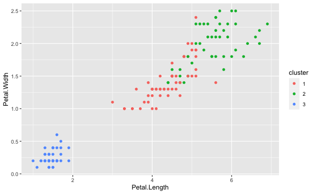

```r
P <- ggplot(data_combinedClusters, aes(x = Petal.Length, y = Petal.Width, color = cluster)) +
  geom_point()

P
```

Below is a plot to better visualize our clusters using Sepal Width vs Sepal length

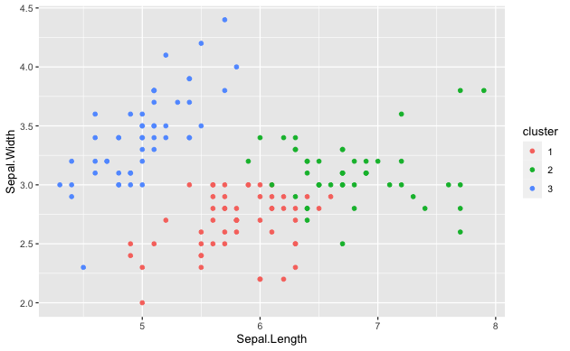

```r
P <- ggplot(data_combinedClusters, aes(x = Sepal.Length, y = Sepal.Width, color = cluster)) +
  geom_point()

P
```

Question 5.1 Using crime data from the file uscrime.txt (http://www.statsci.org/data/general/uscrime.txt, description at http://www.statsci.org/data/general/uscrime.html), test to see whether there are any outliers in the last column (number of crimes per 100,000 people). Use the grubbs.test function in the outliers package in R.

#### Answer

The Grubbs test is based on a normal distribution of the data (Gaussian distribution) so first we have to check if our data is normally distributed. First I plotted the data as a frequency distribution. We can already tell there is a skewness to the data (asymmetry). The right tail is longer so it seems the data is positively skewed [For more info check this site here](https://learningstatisticswithr.com/book/descriptives.html#skewandkurtosis).

To really confirm that our data is not normally distributed we will do a Shapiro-wilk Test. [More info here](https://www.r-bloggers.com/2023/05/checking-normality-in-r/). If the p-value is less than 0.5 then the data is not normally distributed. Our results were W = 0.91273, p-value = 0.001882. Confirming that indeed the Crime datapoints are not normally distributed.

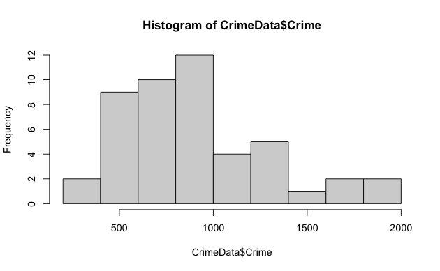

```r
#### Load data and store as variable
CrimeData <- read.table(url("http://www.statsci.org/data/general/uscrime.txt"), header = TRUE)


#### Checking normality of the Crime column datapoints
hist(CrimeData$Crime) #histogram
```

```r
shapiro.test(CrimeData$Crime)
```

```
    Shapiro-Wilk normality test

data:  CrimeData$Crime
W = 0.91273, p-value = 0.001882
```

In order to still perform the Grubbs test we could:

1. Log-transformed the Crime datapoints to make it “more normally distributed”.
2. Re-test normality with the Shapiro test, in this case we got a p value higher than 0.5 when log-transforming, and our histogram has a more Gaussian distribution now.
3. Finally perform the Grubbs test.

Based on the high p value for the Grubbs test , p-value = 0.6329, the test is telling us that our most ‘extreme’ value (G = 2.16544) is most likely not an outlier. The problem with this result is that log-transforming the data can compress the data and “hide” outliers more easily. [More info here](https://www.toolify.ai/ai-news/transform-outliers-and-skewed-data-with-log-transformation-1564967)

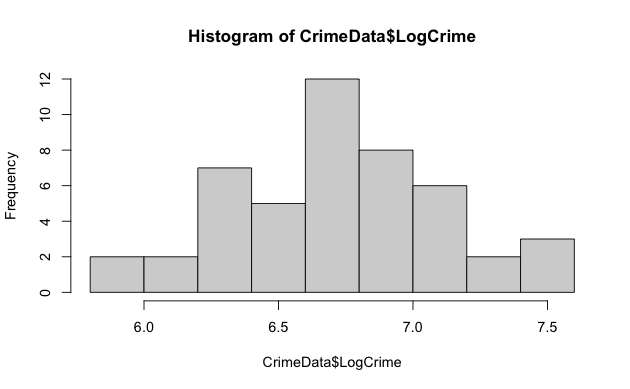

```r
#### Make new column with Log-transformed crime datapoint values

CrimeData$LogCrime <- log(CrimeData$Crime)

#### Re-checking normality of the log-transformed Crime datapoints
hist(CrimeData$LogCrime) #histogram
```

```r
shapiro.test(CrimeData$LogCrime)
```

```
    Shapiro-Wilk normality test

data:  CrimeData$LogCrime
W = 0.98709, p-value = 0.8778
```

```r
#### Grubbs test on log-transformed data
grubbs.test(CrimeData$LogCrime)
```

```
    Grubbs test for one outlier

data:  CrimeData$LogCrime
G = 2.16544, U = 0.89585, p-value = 0.6329
alternative hypothesis: lowest value 5.8348107370626 is an outlier
```

In other words, we could be missing the outliers. We could perform another test to detect outliers that doesn’t assume the data is normally distributed. We can do a whisker plot (boxplot) of the crime datapoints to see if we can visualize/detect point outliers (Sokol Lesson 5.2). This method can detect outliers that fall outside of a reasonable range We do see 3 potential outliers.

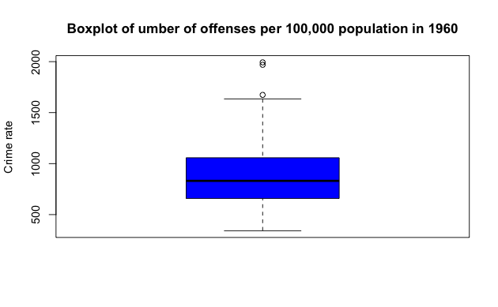

```r
# make a boxplot of the crimes data column
boxplot(CrimeData$Crime,
main = "Boxplot of umber of offenses per 100,000 population in 1960",
ylab = "Crime rate",
col = "blue",
border = "black")
```

```r
summary(CrimeData$Crime)
```

```
   Min. 1st Qu.  Median    Mean 3rd Qu.    Max.
  342.0   658.5   831.0   905.1  1057.5  1993.0
```

Question 6.1

Describe a situation or problem from your job, everyday life, current events, etc., for which a Change Detection model would be appropriate. Applying the CUSUM technique, how would you choose the critical value and the threshold?

A biologist is determining the pH level of cell media for growing cell cultures they can detect changes in cell media as a quality index:

Predictors:

low pH (acidic) medium pH (neutral) high pH (basic)

If there is a deviation from neutral CUSUM can proved insights to the changes.

Question 6.2 1. Using July through October daily-high-temperature data for Atlanta for 1996 through 2015, use a CUSUM approach to identify when unofficial summer ends (i.e., when the weather starts cooling off) each year. You can get the data that you need from the file temps.txt or online, for example at http://www.iweathernet.com/atlanta-weather-records or https://www.wunderground.com/history/airport/KFTY/2015/7/1/CustomHistory.html . You can use R if you’d like, but it’s straightforward enough that an Excel spreadsheet can easily do the job too.

```r
tempData<-data.frame(tempData)

View(tempData)
```

```r
#### fix the headers (remove the X)

colnames(tempData) <- gsub("^X", "", colnames(tempData))
head(tempData)
```

|  | DAY | 1996 | 1997 | 1998 | 1999 | 2000 | 2001 | 2002 | 2003 | 2004 | 2005 | 2006 | 2007 | 2008 | 2009 | 2010 | 2011 | 2012 | 2013 | 2014 | 2015 |
| --- | --- | --- | --- | --- | --- | --- | --- | --- | --- | --- | --- | --- | --- | --- | --- | --- | --- | --- | --- | --- | --- |
| 1 | 1-Jul | 98 | 86 | 91 | 84 | 89 | 84 | 90 | 73 | 82 | 91 | 93 | 95 | 85 | 95 | 87 | 92 | 105 | 82 | 90 | 85 |
| 2 | 2-Jul | 97 | 90 | 88 | 82 | 91 | 87 | 90 | 81 | 81 | 89 | 93 | 85 | 87 | 90 | 84 | 94 | 93 | 85 | 93 | 87 |
| 3 | 3-Jul | 97 | 93 | 91 | 87 | 93 | 87 | 87 | 87 | 86 | 86 | 93 | 82 | 91 | 89 | 83 | 95 | 99 | 76 | 87 | 79 |
| 4 | 4-Jul | 90 | 91 | 91 | 88 | 95 | 84 | 89 | 86 | 88 | 86 | 91 | 86 | 90 | 91 | 85 | 92 | 98 | 77 | 84 | 85 |
| 5 | 5-Jul | 89 | 84 | 91 | 90 | 96 | 86 | 93 | 80 | 90 | 89 | 90 | 88 | 88 | 80 | 88 | 90 | 100 | 83 | 86 | 84 |
| 6 | 6-Jul | 93 | 84 | 89 | 91 | 96 | 87 | 93 | 84 | 90 | 82 | 81 | 87 | 82 | 87 | 89 | 90 | 98 | 83 | 87 | 84 |

We are going to reshape the data from a “wide format” to a long format , it’s easier for plotting

```r
#### Reshape data
tempDatalong <- tempData %>% pivot_longer(cols = -DAY, # grab all columns except Day
                                          names_to = "Year", #make new column called year add headers here
                                          values_to = "Temperature") # take all of the datapoints from the years and add to new column called temp

head(tempDatalong)
```

| DAY | Year | Temperature |
| --- | --- | --- |
| 1-Jul | 1996 | 98 |
| 1-Jul | 1997 | 86 |
| 1-Jul | 1998 | 91 |
| 1-Jul | 1999 | 84 |
| 1-Jul | 2000 | 89 |
| 1-Jul | 2001 | 84 |

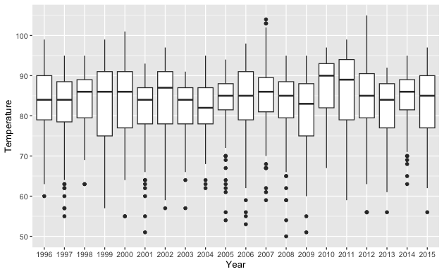

```r
#### Exploratory plot

ggplot(tempDatalong, aes(x = Year, y = Temperature)) +
       geom_boxplot()
```

Summary:

Outliers were observed in the lower temperatures. Temperature medians stayed between 80-90 degree throughout the years.

Now we want to look at the average temperature over the years. We can calculate the mean temp per year and obtain the standard deviation using group_by (dplyr package) and then plot it. [Stack overflow example](https://stackoverflow.com/questions/46661461/calculate-mean-by-group-using-dplyr-package)

```r
#### Get the average daily temp


Average_daily_Temperature <- tempDatalong %>% group_by(DAY) %>% summarise(Average_Temperature = mean(Temperature))
head(Average_yearly_Temperature)
```

[output not shown]

```r
Average_daily_Temperature$DAY <- as.Date(Average_daily_Temperature$DAY, format = "%d-%b") #make sure the Day column is the right data type (or else it will not to plot!)



print(head(Average_daily_Temperature))
```

| DAY | Average_Temperature |
| --- | --- |
| 2024-08-01 | 88.55 |
| 2024-07-01 | 88.85 |
| 2024-10-01 | 77.10 |
| 2024-09-01 | 85.25 |
| 2024-08-10 | 89.25 |
| 2024-07-10 | 88.55 |

```r
NA
NA
NA
NA
NA
NA
```

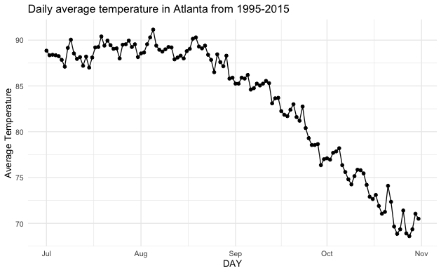

```r
#### Plot our yearly average temperature !

ggplot(Average_daily_Temperature, aes(x = DAY, y = Average_Temperature, group = 1)) + #"group = 1" all points are 1 group
  geom_line() +
  geom_point() +
  theme_minimal() +
  labs(title = "Daily average temperature in Atlanta from 1995-2015",
       y = "Average Temperature")
```

Months July to August seem to be the highest temperature with a dip in September. The month of july is also fairly stable, this will come in handy for using this month as a baseline for CUSUM.

###Using the CUSUM approach to detect changes in yearly average temperatures

The CUSUM approach accumulates the changes between individual datapoints and a target value (mean) over time. For each point in a time series dataset, the deviation from the mean is calculated. If this deviation is positive it is added to the CUSUM sum; If the deviation is negative , it resets to zero.

Mathematically, for our particular data , we can look at the CUSUM approach in this way:

1. Average_daily_Temperature = average daily temperature for all years in the Atlanta dataset
2. july_mean = Total Mean or average of the baseline temperature (month of july, this was obtained from the plot above)
3. T = Threshold
4. C = (sometimes called k), ‘slack’, its a parameter that helps adjust the sensitivity of the model- I kept it low to be more “sensitive”

We can create a loop that uses the CUSUM formula to go over daily temperatures across the years to determine deviations from the average and obtain a CUSUM value. For our temperature dataset, high CUSUM values can mean higher than average temperatures. If the CUSUM values go back to zero often, this can mean the temperature are staying stable throughout the years.

Before doing the loop lets first grab the july temperatures to calculate the average temperature for the month of July throughout the years

```r
#### filter the data for July months
july_baseline <- Average_daily_Temperature %>%  filter(format(DAY,"%b")=="Jul")

#### Get the average temperature for the july month

july_mean <- mean(july_baseline$Average_Temperature)
print(july_mean)
```

```
[1] 88.75
```

88.75 is our average temperature for July.

Create a loop testing CUSUM: In this case I manually changed the C and T values (brute force), choosing C and T values was not simple. Based on the plot above I kept the values conservative.

```r
#### Parameter setting

C <- 1
T<- .5

#variables for storage

Cusum_values <- numeric(nrow(Average_daily_Temperature))
#Cusum[1] <- 0 #start CUSUM at zero for the first year

#### CUSUM loop through each year (i)

for (i in 2:nrow(Average_daily_Temperature)){

  Cusum_values[i] <- max(0, Cusum_values[i-1] + ( Average_daily_Temperature$Average_Temperature[i] - july_mean - (C + T) ) )


}
```

Ok now we will save the values and plot them to visually insect the data

```r
  Average_daily_Temperature$CusumValues <- Cusum_values
print(Average_daily_Temperature)
```

| DAY | Average_Temperature | CusumValues |
| --- | --- | --- |
| 2024-08-01 | 88.55 | 0.00 |
| 2024-07-01 | 88.85 | 0.00 |
| 2024-10-01 | 77.10 | 0.00 |
| 2024-09-01 | 85.25 | 0.00 |
| 2024-08-10 | 89.25 | 0.00 |
| 2024-07-10 | 88.55 | 0.00 |
| 2024-10-10 | 75.15 | 0.00 |
| 2024-09-10 | 85.25 | 0.00 |
| 2024-08-11 | 89.20 | 0.00 |
| 2024-07-11 | 87.95 | 0.00 |

[output cut: 113 more lines]

```r
NA
NA
NA
```

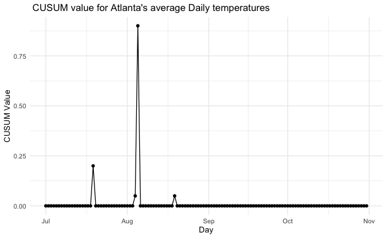

```r
ggplot(Average_daily_Temperature, aes(x = DAY, y= CusumValues)) +
         geom_line()+
         geom_point() +
         theme_minimal() +
  labs(x = "Day", y = "CUSUM Value", title = " CUSUM value for Atlanta's average Daily temperatures")
```

```r
NA
```

Before doing the loop lets first grab the August temperatures to calculate the average temperature for the month of August throughout the years

```r
#### filter the data for July months
august_baseline <- Average_daily_Temperature %>%  filter(format(DAY,"%b") =="Aug")

#### Get the average temperature for the july month

august_mean <- mean(august_baseline$Average_Temperature)
print(august_mean)
```

```
[1] 88.61613
```

```r
#### Parameter setting

C <- 1
T<- .5

#variables for storage

Cusum_values_aug <- numeric(nrow(august_baseline))


#### CUSUM loop through each year (i)

for (i in 2:nrow(august_baseline)){

  Cusum_values_aug[i] <- max(0, Cusum_values_aug[i-1] + ( august_baseline$Average_Temperature[i] - august_mean - (C + T) ) )
}
```

Ok now we will save the values and plot them to visually inspect the data

```r
august_baseline$CusumValues_aug <- Cusum_values_aug
print(august_baseline)
```

| DAY | Average_Temperature | CusumValues | CusumValues_aug |
| --- | --- | --- | --- |
| 2024-08-01 | 88.55 | 0.00 | 0.00000000 |
| 2024-08-10 | 89.25 | 0.00 | 0.00000000 |
| 2024-08-11 | 89.20 | 0.00 | 0.00000000 |
| 2024-08-12 | 87.90 | 0.00 | 0.00000000 |
| 2024-08-13 | 88.10 | 0.00 | 0.00000000 |
| 2024-08-14 | 88.30 | 0.00 | 0.00000000 |
| 2024-08-15 | 88.00 | 0.00 | 0.00000000 |
| 2024-08-16 | 88.80 | 0.00 | 0.00000000 |
| 2024-08-17 | 89.05 | 0.00 | 0.00000000 |
| 2024-08-18 | 90.15 | 0.00 | 0.03387097 |

[output cut: 21 more lines]

```r
NA
NA
NA
```

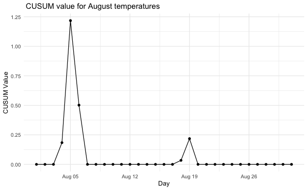

```r
ggplot(august_baseline, aes(x = DAY, y= CusumValues_aug)) +
         geom_line()+
         geom_point() +
         theme_minimal() +
  labs(x = "Day", y = "CUSUM Value", title = " CUSUM value for August temperatures")
```

```r
NA
```